# Cox PH Regression: Checking PH Assumption

Lecture 8B

PUBHBIO 6250

## Advantages of Cox PH Model

1. Estimation of predictor effect $\beta$ **does not require the baseline hazard $h_0(t)$**.
   - No need to model $h_0(t)$ when estimating $\beta$, making the model robust to $h_0(t)$.
   - This is a **semi-parametric** model where $\beta$ is the parametric part and $h_0(t)$ is the nonparametric part.
2. The effect of a predictor is summarized by a single quantity $\beta$ under the **proportional hazards (PH) assumption**.
   - It is easy to interpret and communicate the modeling results.

The PH assumption may not hold and its violation needs to be addressed.

## Checking PH Assumption

- The PH assumption is required for the validity of the Cox regression model.
- The PH assumption is not always reasonable.

  *Examples*:
  - A treatment may require several months to become effective.
  - Patient characteristics at surgery may affect early but not long-term survival.
- It is critical to check if the PH assumption is plausible in the dataset.
- We will discuss **two popular PH checking methods**:
  1. Log-log survival plot.
  2. Testing interaction with time.

## Check PH: Log-Log Survival Plot

- Works when a Cox PH model only contains **one categorical predictor** $x$.
- Assume $x$ is binary.
- Let $S_1(t)$ and $S_0(t)$ be the survival functions when $x = 1$ and 0, respectively.
- If the proportional hazards assumption holds:

$$S_1 (t) = [S_0(t)]^{\exp(\beta_1)}$$

- Taking the log-log transformation

$$\begin{aligned}
\log\{-\log[S_1(t)]\} &= \log \{ -\log \{ [S_0(t)]^{\exp(\beta_1)} \}\} \\
&= \log \{ - \exp(\beta_1) \log[S_0(t)]\} \\
&= \log \{-\log[S_0(t)]\} + \beta_1
\end{aligned}$$

$\Rightarrow$ $\log\{-\log[S_1(t)]\} - \log \{-\log[S_0(t)]\} = \beta_1$

## Check PH: Log-Log Survival Plot (Cont’d)

- To check PH:
  1. Calculate the Kaplan-Meier curve for each group (estimates of $S_1(t)$ and $S_0(t)$).
  2. Take log-log transformation of each curve and plot it.
  3. Examine whether the vertical distance between the curves is the same over time.

     **Note**: Under the PH assumption, $\log\{-\log[S_1(t)]\} - \log \{-\log[S_0(t)]\} = \beta_1$.
- Can be easily extended to **categorical predictors with more than two levels**.
  - Generate and plot $\log\{-\log[S(t)]\}$ for each level of the predictor.
  - If the vertical distance between **any** two curves changes over time, the PH assumption is violated for the categorical predictor.

## Example: Log-Log Survival Plot

**Task**: Check the PH assumption for the binary predictor DPCA in the DPCA study.

**Using log-log survival plot**:

- Calculate the survival function for DPCA=0 and 1 separately using the Kaplan-Meier estimator.
- Plot the log-log transformed survival functions for the two groups.
- Examine the vertical distance between the two curves.

## Example: Log-Log Survival Plot

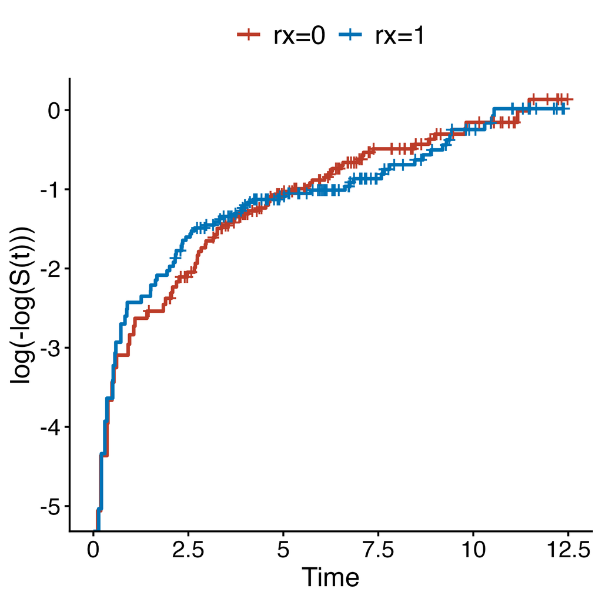

- Although the vertical distance changes over time, it is in general very small.
- The two curves are basically intertwined with each other. Any change in the distance may be due to random fluctuation.
- This is an example where the log-log survival plot method is inconclusive.

## Limitations of Log-Log Survival Plot

- Assessing the vertical distance between log-log survival curves is subjective.
  - Plots are well suited for identifying **gross violations** of the PH assumption.
  - May not be useful if the curves are not well separated.
- Can only check PH assumption univariately, one predictor at a time.
- Cannot be used for continuous predictors.
  - **Possible solution**: Discretize the continuous predictor into several categories and plot the curves for each category.

    **Concerns**: Sensitive to categorization and inconsistent with how the variable is treated in the model.

## Check PH: Testing Interaction with Time

- Assume $x$ is the only predictor in a Cox PH model.
- To check the PH assumption for $x$, consider a model with an interaction between $x$ and a function of time $g(t)$:

$$\begin{aligned}
h(t|x) &= h_0(t) \exp \left\{\beta_1 x + \beta_2 g(t) x \right\} \\
&= h_0(t) \exp\left\{\textcolor{#0000FF}{(\beta_1+ \beta_2 g(t))} x\right\}
\end{aligned}$$

- The total effect of $x$ is **$\beta_1 + \beta_2 g(t)$**.
- If the effect changes over time, then the PH assumption is violated for $x$.
- We can check the PH assumption by testing the null hypothesis $H_0: \beta_2 = 0$.
  - If $H_0$ is **rejected**, the PH assumption is **violated**.

## Check PH: Testing Interaction with Time (Cont’d)

- $g(t)$ is chosen by the researcher; commonly used functions are **$\log(t)$** and **$t$**.
- **A common strategy in practice**: try both $\log(t)$ and $t$.

  Rejection of $H_0: \beta_2 = 0$ for either indicates the PH assumption is violated.
- Can be extended to **multiple predictors** by including **multiple interaction terms**.
- **NOTE**: It is incorrect to generate the interaction term as the product of the survival time variable in the dataset and the predictor.
- **Interaction terms must be generated using specialized functions in statistical software**:
  - STATA: `tvc` option in `stcox` command.
  - R: `tt` parameter in `coxph` function.
  - SAS: add statement `xt = x*g(t)` after `model` statement in `phreg` procedure.

## Example: Interaction with Time

- In the DPCA study, we fit a Cox model with predictors DPCA and bilirubin.
- Assess the PH assumption for these predictors based on interaction with time.

  We chose **$g(t) = t$** and the resulting Cox PH model is:

$$h(t | x) = h_0(t) \exp(\beta_1 \texttt{rx} + \beta_2 \texttt{bilirub} + \textcolor{#0000FF}{\beta_3 t \times \texttt{rx}} + \textcolor{#C41A8A}{\beta_4 t \times \texttt{bilirub}})$$

- Wald test for $H_0: \textcolor{#0000FF}{\beta_3} = 0$ to check the PH assumption for DPCA.

  $\rightarrow p$-value = 0.979 $\rightarrow$ PH assumption is satisfied for DPCA.
- Wald test for $H_0: \textcolor{#C41A8A}{\beta_4} = 0$ to check the PH assumption for bilirubin.

  $\rightarrow p$-value = 0.004 $\rightarrow$ PH assumption is violated for bilirubin.

  To fix the PH violation for bilirubin, all we need to do is to **keep the interaction $t \times \texttt{bilirub}$ in the model**.

## Example: Interaction with Time (Cont’d)

The final model for the DPCA study is

$$h(t | x) = h_0(t) \exp(\beta_1 \texttt{rx} + \beta_2 \texttt{bilirub} + \textcolor{#C41A8A}{\beta_3 t \times \texttt{bilirub}})$$

[output not shown]

## Report Time-Varying Hazard Ratio

$$h(t | x) = h_0(t) \exp \left\{ \beta_1 \texttt{rx} + \textcolor{#0000FF}{(\beta_2 + \beta_3 t)} \times \texttt{bilirub} \right\}$$

## Report Time-Varying Hazard Ratio (Cont’d)

- Alternatively, we can **plot the time-varying HR** (i.e., $\exp(0.010+0.023\times t)$) over time $t$ to show its entire trajectory over the follow-up period.
  - X-axis = follow-up time ($t$) and Y-axis = estimated hazard ratio

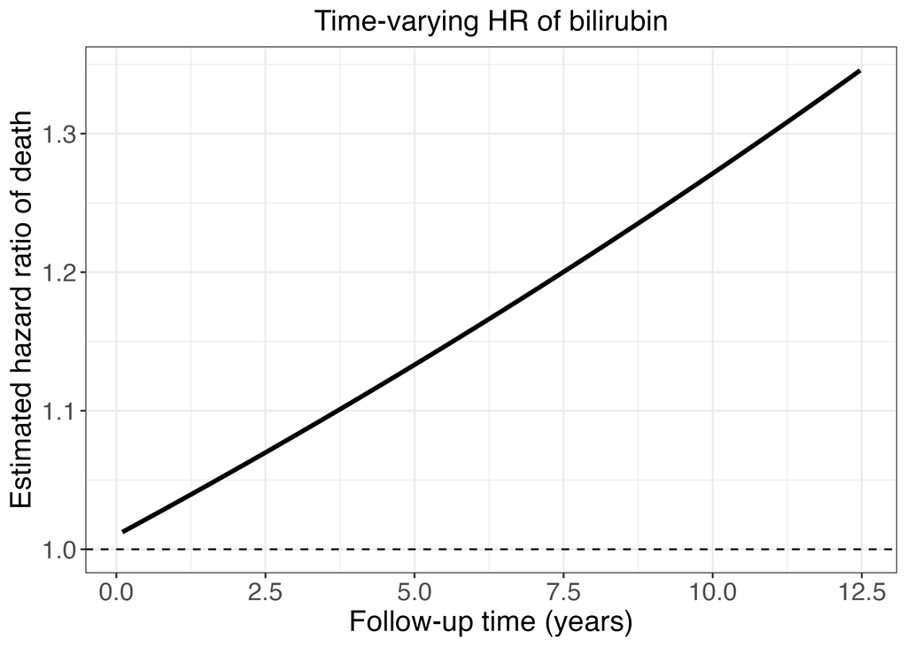